# Customer Satisfaction Task

# Overview

The Chief Operating Officer of a wireless phone company, TelCo Inc., has noticed that the company’s customer satisfaction scores have been dropping. Additionally, the call volume in their customer service center has been increasing, which is driving increased operating costs. They Gave us this data to try to understand the reasons behind this and a recommendations to handle it.

```python
import pandas as pd
import numpy as np
import matplotlib.pyplot as plt
import seaborn as sb
%matplotlib inline
#Importing Libraries
```

```python
cst_sts_res=pd.read_excel('Dataset - Data Analyst Vacancy.xlsx',sheet_name='Customer Satisfaction Results')
act_inter=pd.read_excel('Dataset - Data Analyst Vacancy.xlsx',sheet_name='Account Interactions')
Ag_Info=pd.read_excel('Dataset - Data Analyst Vacancy.xlsx',sheet_name='Agent Information')
```

```python
full_data=pd.merge(cst_sts_res,act_inter,on='Interaction ID')
```

```python
full_data.drop(columns=['Account Number_y','Call Date_y','Agent ID_y'],inplace =True)
```

### We start this with the correlation Matrix, It tells us the stranght of correlation between features, The darker the color the stronger the correlation, This visual tells us that Overall Experience is has a moderted correlation with (Agent Quality of servie, Resolve Issue and Knowledge), Also a strong Correlation with (Courteous)

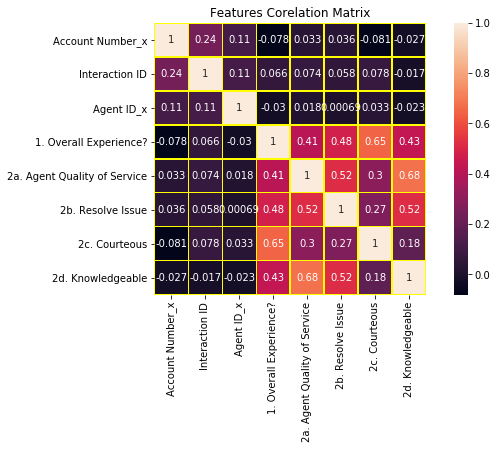

```python
plt.figure(figsize=(10,5))
ax=sb.heatmap(full_data.corr(),annot=True,linewidths=0.5,annot_kws={"size": 10},linecolor="yellow",square=True,);
bottom , top = ax.get_ylim()
ax.set_ylim(bottom +0.5,top -0.5)
plt.title("Features Corelation Matrix");
```

### As we see the more Courteous from the agent the more possibility the customer would be satisfied, Infact seeing the density tells as it has a great effect on making the customer enjoys the call, the less rated as 2 is very diversed and that decrease the chances of insuring the customer would be satisfied.

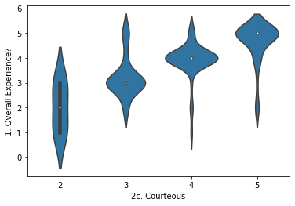

```python
base_c=sb.color_palette()[0]
sb.violinplot(x=full_data['2c. Courteous'],y=full_data['1. Overall Experience?'],color=base_c);
```

### As we see also the more Quality of Service from the agent the more possibility the customer would be satisfied, Most of high rated Overall exp. had a high quality service, Rated 1 and 2 hae a relatively low quality of service.

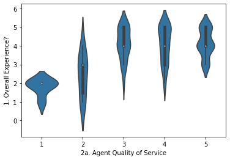

```python
sb.violinplot(x=full_data['2a. Agent Quality of Service'],y=full_data['1. Overall Experience?'],color=base_c);
```

### Again we see also the more Resolve Issue quality from the agent the more possibility the customer would be satisfied, Most of high rated Overall exp. had a Resolve Issue ratings , Rated 1 and 2 hae a relatively low quality of Resolving Issue.

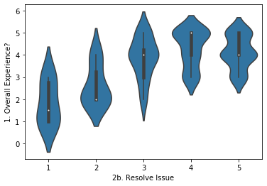

```python
sb.violinplot(x=full_data['2b. Resolve Issue'],y=full_data['1. Overall Experience?'],color=base_c);
```

### As we see also the more Knowledge from the agent the more possibility the customer would be satisfied, Most of high rated Overall exp. had a high quality service, Rated 1 and 2 hae a relatively low quality of service.

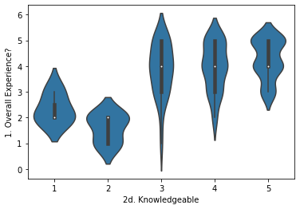

```python
sb.violinplot(x=full_data['2d. Knowledgeable'],y=full_data['1. Overall Experience?'],color=base_c);
```

### We notice from the previous plots that ratings from 3-5 nearly all of them requires an average of 4 or higher rating in the other 4 features, Agents being rated 4 or above in other features will surely gain a pleasable customer satisfiction.

### We can see all poor(1) Overall exp. calls were about add service, Rated fair(2) are mostly also about add service and with smaller values (Make payment and Handset Questions)

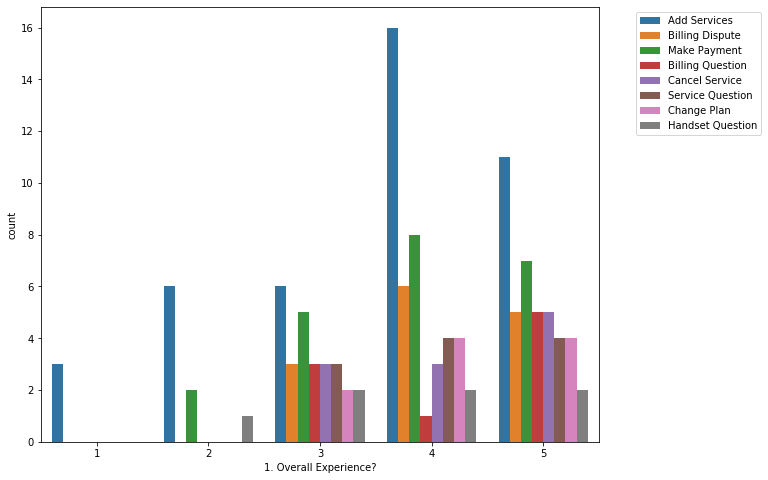

```python
plt.figure(figsize=(10,8))
sb.countplot(x=full_data['1. Overall Experience?'],hue=full_data['Call Reason'])
plt.legend(loc='upper right', bbox_to_anchor=(1+.3,1))
plt.show()
```

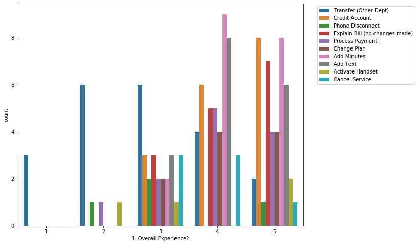

```python
plt.figure(figsize=(10,8))
sb.countplot(x=full_data['1. Overall Experience?'],hue=full_data['Call Resolution'])
plt.legend(loc='upper right', bbox_to_anchor=(1+.4,1))
plt.show()
```

### We can see here some agents rating mean is quit low especially agent 10, Agents 1,4 and 5 also need improvement to atleast have an average of rating = 4 to ensure customer satisfiction.

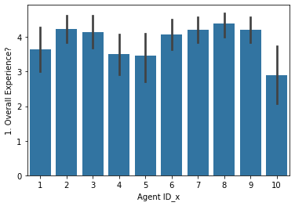

```python
sb.barplot(x=full_data['Agent ID_x'],y=full_data['1. Overall Experience?'],color=base_c);
```

### This plot is to observe any common trait between the four agents, it's more obvious now, Those agents are hired recently and lacked of experience.

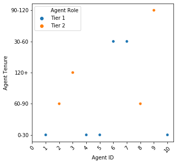

```python
plt.figure(figsize=(5,5))
x_bins=np.arange(0, 11, step=1)
sb.scatterplot(y=Ag_Info['Agent Tenure'],x=Ag_Info['Agent ID'],hue=Ag_Info['Agent Role'],color=base_c)
plt.xticks(x_bins,rotation=45)
plt.show()
```

## Conclusions

#### Some potential drivers of the decreased customer satisfaction and increased call volume :

#### According to my findings :

#### (A) Lacking in agent's (Knoweldge, Service quality, Issue resolving leads to less customer satisfaction and increased call volume.

#### (B) Courteous is the most important feature here in affecting customer's satisfaction, It has a strong relation with customer's overall experience.

#### (C) Nearly all Poor and Fair ratings related to customers who request Adding servies and the agent fails to satisfy them.

#### (D) Nearly all poor and fair ratings related to transfering the call to other dep. or call disconecting.

#### Some potential recommendations to improve these issues :

#### (A) Demanding agents with average less than 4 in Knowledge feature to revise and enhance their knowledge.

#### (B) Emphasize the importance of Courteous with customers.

#### (C) Agents with service quality or issue resolving average less than 4 need to improve to achieve high customer satisfaction.

#### (D) If it's possible to reduce amount of calls about 'Adding service' to recently hired agents would be a good approach.

#### (E) The company should consider revising the call transfering protocols or increase observing transfering calls reasons.

#### Benefits of implementing these recommendations :

#### (A) Mainly lacking in knowledge would inreases the call volume and cause less customer's satisfaction, So improvement from agents is needed.

#### (B)Courteous is greatly affecting customers overall experience, Emphasize the importance of is important and causes customer's satisfaction to increase.

#### (C)The more service quality and problem solving from the agent the more the customer gets satisfied and the less call duration.

#### (D)Reducing amount of calls about 'Adding service' to recently hired agents to let them gain experience with less harm to Customer's satisfaction as all poor rated calls are about 'Adding Service'

#### (E)Transfering calls to other department upsets many customers for a reason, The company should revise the transfering protocols to avoid wasting the customer's time without any need or misunderstanding from the agent which also increases the call duration and would make the customer consider this as a bad experience.